# Project 06 — Advanced Meridian MMM with External Regressors

## Bootstrap + Posterior Predictive ROAS Confidence Intervals

**Rationale:** Propagates full uncertainty (parameter + sampling) into business metrics. A point-estimate ROAS of 3.2x can become 1.8–4.8x under full uncertainty — a range that changes the budget recommendation.

**Blueprint:** Sample from posterior -> recompute mROI distribution -> report P10/P50/P90 ROAS.

```
Drawing 500 posterior samples for ROAS distribution...

=== ROAS sanity check ===
  tv          median=1.23x  p10=0.89x  p90=1.58x
  search      median=1.72x  p10=1.45x  p90=2.02x
  display     median=1.44x  p10=0.78x  p90=2.11x
  social      median=1.19x  p10=0.66x  p90=1.70x
  email       median=1.58x  p10=0.43x  p90=2.98x
```

ROAS P10/P50/P90 -- full uncertainty propagation (N=500 posterior draws)

| Channel | P10 ROAS | P50 ROAS | P90 ROAS | Mean ROAS | Std ROAS | CI width |
| --- | --- | --- | --- | --- | --- | --- |
| Search | 1.45 | 1.72 | 2.02 | 1.73 | 0.21 | 0.57 |
| Email | 0.43 | 1.58 | 2.98 | 1.63 | 0.93 | 2.55 |
| Display | 0.78 | 1.44 | 2.11 | 1.44 | 0.51 | 1.32 |
| Tv | 0.89 | 1.23 | 1.58 | 1.22 | 0.27 | 0.69 |
| Social | 0.66 | 1.19 | 1.70 | 1.19 | 0.40 | 1.04 |

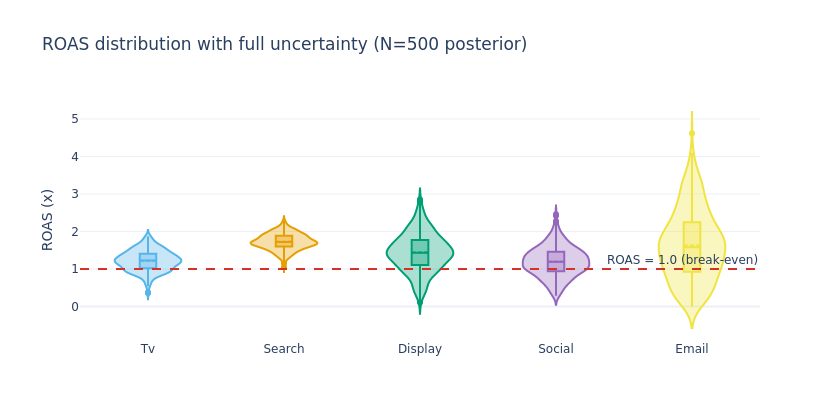

```python
# ── ROAS Confidence Intervals (leave-one-channel-out) ───────────────
N_BOOT = 500
y_arr  = np.asarray(df['sales'].values, dtype=float)

roas_distributions = {ch: [] for ch in MEDIA_CHANNELS}

# media column positions in ALL_FEAT_COLS (raw, unscaled)
media_col_idx = [ALL_FEAT_COLS.index(f'{ch}_sat') for ch in MEDIA_CHANNELS]

# raw feature matrix (unscaled) — LOO zeroing happens here
X_raw_base = df[ALL_FEAT_COLS].values.copy()

if USING_PYMC:
    beta_media_draws   = trace.posterior['beta_media'].values
    beta_ext_draws     = trace.posterior['beta_ext'].values
    beta_fourier_draws = trace.posterior['beta_fourier'].values
    intercept_draws    = trace.posterior['intercept'].values

    flat_bm  = beta_media_draws.reshape(-1, len(MEDIA_FEAT_COLS))
    flat_be  = beta_ext_draws.reshape(-1, len(EXT_FEAT_COLS))
    flat_bf  = beta_fourier_draws.reshape(-1, len(FOURIER_COLS))
    flat_int = intercept_draws.reshape(-1)

    sample_idx = np.random.choice(flat_bm.shape[0], N_BOOT, replace=True)
    print(f"Drawing {N_BOOT} posterior samples for ROAS distribution...")

    # y_full computed once per sample on full scaled matrix
    y_std  = y_arr.std()
    y_mean = y_arr.mean()

    for s_idx in sample_idx:
        beta_all  = np.concatenate([flat_bm[s_idx], flat_be[s_idx], flat_bf[s_idx]])
        intercept = flat_int[s_idx]

        y_full = (intercept + Xs_full @ beta_all) * y_std + y_mean

        for ci, ch in enumerate(MEDIA_CHANNELS):
            X_raw_loo = X_raw_base.copy()
            X_raw_loo[:, media_col_idx[ci]] = 0.0
            Xs_loo = scaler_full.transform(X_raw_loo)

            y_loo       = (intercept + Xs_loo @ beta_all) * y_std + y_mean
            attributed  = (y_full - y_loo).sum()
            total_spend = df[f'{ch}_spend'].sum()
            roas_distributions[ch].append(attributed / (total_spend + 1e-6))
else:
    print(f"PyMC unavailable -- bootstrapping {N_BOOT} resamples for ROAS CI...")
    n_obs = len(y_arr)
    for b in range(N_BOOT):
        idx    = np.random.choice(n_obs, n_obs, replace=True)
        m_b    = Ridge(alpha=1.0).fit(Xs_full[idx], y_arr[idx])
        y_full = m_b.predict(Xs_full)

        for ci, ch in enumerate(MEDIA_CHANNELS):
            # Zero in raw space = true no-spend, then re-scale
            X_raw_loo = X_raw_base.copy()
            X_raw_loo[:, media_col_idx[ci]] = 0.0
            Xs_loo    = scaler_full.transform(X_raw_loo)

            y_loo      = m_b.predict(Xs_loo)
            attributed = (y_full - y_loo).sum()
            total_spend = df[f'{ch}_spend'].sum()
            roas_distributions[ch].append(attributed / (total_spend + 1e-6))

# ── Sanity check ──────────────────────────────────────────────────────────────
print("\n=== ROAS sanity check ===")
for ch in MEDIA_CHANNELS:
    dist = np.array(roas_distributions[ch])
    print(f"  {ch:10s}  median={np.median(dist):.2f}x  "
          f"p10={np.percentile(dist,10):.2f}x  p90={np.percentile(dist,90):.2f}x")

# ── Summary table ─────────────────────────────────────────────────────────────
roas_rows = []
for ch in MEDIA_CHANNELS:
    dist = np.array(roas_distributions[ch])
    roas_rows.append({
        'Channel':   ch.title(),
        'P10 ROAS':  round(np.percentile(dist, 10), 2),
        'P50 ROAS':  round(np.percentile(dist, 50), 2),
        'P90 ROAS':  round(np.percentile(dist, 90), 2),
        'Mean ROAS': round(dist.mean(), 2),
        'Std ROAS':  round(dist.std(), 2),
        'CI width':  round(np.percentile(dist, 90) - np.percentile(dist, 10), 2),
    })

df_roas_ci = pd.DataFrame(roas_rows).sort_values('P50 ROAS', ascending=False)
src = 'posterior' if USING_PYMC else 'bootstrap'
display(df_roas_ci.style
    .background_gradient(subset=['P50 ROAS'], cmap='RdYlGn', vmin=0, vmax=df_roas_ci['P50 ROAS'].max() * 1.2)
    .format('{:.2f}', subset=['P10 ROAS','P50 ROAS','P90 ROAS','Mean ROAS','Std ROAS','CI width'])
    .set_properties(**{'font-size': '11px'})
    .hide(axis='index')
    .set_caption(f'ROAS P10/P50/P90 -- full uncertainty propagation (N={N_BOOT} {src} draws)'))

# ── Violin plot ───────────────────────────────────────────────────────────────
def hex_to_rgba(hex_color, alpha=0.33):
    h = hex_color.lstrip('#')
    r, g, b = int(h[0:2], 16), int(h[2:4], 16), int(h[4:6], 16)
    return f'rgba({r},{g},{b},{alpha})'

fig_roas = go.Figure()
colors = [f'{C_SKY}', f'{C_ORANGE}', f'{C_GREEN}', f'{C_PURPLE}', f'{C_YELLOW}']
for ci, ch in enumerate(MEDIA_CHANNELS):
    fig_roas.add_trace(go.Violin(
        x=[ch.title()] * N_BOOT, y=roas_distributions[ch],
        name=ch.title(), box_visible=True, meanline_visible=True,
        fillcolor=hex_to_rgba(colors[ci], 0.33),
        line_color=colors[ci]
    ))
fig_roas.add_hline(y=1.0, line_dash='dash', line_color=f'{C_NEGATIVE}',
                   annotation_text='ROAS = 1.0 (break-even)')
fig_roas.update_layout(
    height=420, width=840, template=PLOTLY_TEMPLATE,
    title=f'ROAS distribution with full uncertainty (N={N_BOOT} {src})',
    yaxis_title='ROAS (x)', showlegend=False,
    font=dict(family=FONT_FAMILY, size=12)
)
fig_roas.show()
```

## Full ArviZ Posterior Diagnostics (ESS, R-hat, Rank Plots, PPC)

**Rationale:** MCMC validity is non-negotiable. A low ESS or R-hat > 1.01 means the sampler has not converged and coefficient estimates are unreliable — no amount of downstream analysis on a non-converged chain is valid.

**Blueprint:** `az.plot_ppc()`, `az.summary()`, `az.plot_rank()` in a dedicated diagnostics cell.

```
-- MCMC Convergence Summary --
```

|  | mean | sd | eti89_lb | eti89_ub | ess_bulk | ess_tail | r_hat | mcse_mean | mcse_sd |
| --- | --- | --- | --- | --- | --- | --- | --- | --- | --- |
| beta_ext[0] | -0.137 | 0.0249 | -0.1800 | -0.098 | 1352 | 1055 | 1.00 | 0.00068 | 0.00047 |
| beta_ext[1] | -0.133 | 0.0249 | -0.1700 | -0.094 | 1721 | 1377 | 1.00 | 0.00060 | 0.00043 |
| beta_ext[2] | -0.060 | 0.0248 | -0.1000 | -0.020 | 1777 | 1197 | 1.00 | 0.00059 | 0.00040 |
| beta_ext[3] | 0.076 | 0.0228 | 0.0400 | 0.110 | 1819 | 1170 | 1.00 | 0.00053 | 0.00039 |
| beta_media[0] | 0.307 | 0.0720 | 0.1900 | 0.420 | 830 | 793 | 1.00 | 0.00250 | 0.00180 |
| beta_media[1] | 0.488 | 0.0590 | 0.3900 | 0.580 | 1111 | 984 | 1.00 | 0.00180 | 0.00120 |
| beta_media[2] | 0.198 | 0.0670 | 0.0920 | 0.310 | 729 | 574 | 1.00 | 0.00250 | 0.00170 |
| beta_media[3] | 0.150 | 0.0480 | 0.0710 | 0.230 | 964 | 774 | 1.01 | 0.00150 | 0.00100 |
| beta_media[4] | 0.059 | 0.0350 | 0.0091 | 0.120 | 865 | 551 | 1.00 | 0.00093 | 0.00061 |
| intercept | 0.001 | 0.0221 | -0.0360 | 0.037 | 1731 | 989 | 1.00 | 0.00053 | 0.00038 |
| sigma | 0.311 | 0.0159 | 0.2900 | 0.340 | 1831 | 1125 | 1.00 | 0.00037 | 0.00026 |

```
Sampling: [y_obs]
```

```
Output()
```

```
All R-hat <= 1.01 -- chains converged
All bulk ESS >= 400 -- sufficient effective samples

-- Posterior Predictive Check --
```

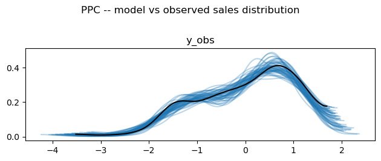

```
-- Rank plots (uniform bars = good chain mixing) --
```

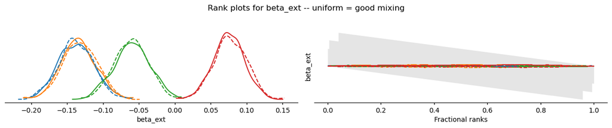

```
-- Chain traces (overlapping chains = good mixing) --
```

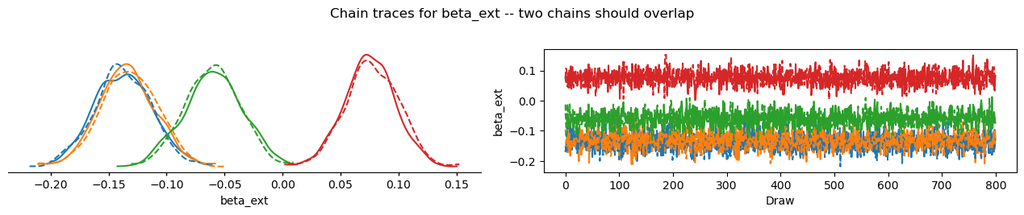

```python
# ArviZ Posterior Diagnostics

if PYMC_AVAILABLE and USING_PYMC:

    # ── Convergence Summary ───────────────────────────────────────────────────
    print("\n-- MCMC Convergence Summary --")
    summary = azs.summary(trace, var_names=['beta_ext', 'beta_media', 'intercept', 'sigma'])

    # ArviZ 1.1.0 returns numeric columns as object dtype — coerce before filtering
    for col in ['mean', 'sd', 'eti89_lb', 'eti89_ub', 'ess_bulk', 'ess_tail',
                'r_hat', 'mcse_mean', 'mcse_sd']:
        if col in summary.columns:
            summary[col] = pd.to_numeric(summary[col], errors='coerce')

    display(summary)

    bad_rhat = summary[summary['r_hat'] > 1.01]
    low_ess  = summary[summary['ess_bulk'] < 400]

    if len(bad_rhat):
        print(f"\nWARN: R-hat > 1.01: {bad_rhat.index.tolist()} -- run more samples!")
    else:
        print("\nAll R-hat <= 1.01 -- chains converged")

    if len(low_ess):
        print(f"WARN: Low bulk ESS: {low_ess.index.tolist()} -- increase tune/draws")
    else:
        print("All bulk ESS >= 400 -- sufficient effective samples")

    EXEC_METRICS['max_rhat'] = float(summary['r_hat'].max())
    EXEC_METRICS['min_ess']  = float(summary['ess_bulk'].min())

    # ── Posterior Predictive Check ────────────────────────────────────────────
    print("\n-- Posterior Predictive Check --")

    from arviz_plots import plot_ppc_dist, plot_rank_dist, plot_trace_dist

    _has_ppc = (
        'posterior_predictive' in [c.lstrip('/') for c in trace.children]
        and 'obs' in trace['posterior_predictive'].dataset
    )
    if not _has_ppc:
        with mmm:
            _ppc = pm.sample_posterior_predictive(trace, random_seed=RANDOM_SEED)
        trace.update(_ppc)

    plot_ppc_dist(trace)
    plt.suptitle("PPC -- model vs observed sales distribution", y=1.02)
    plt.tight_layout()
    plt.show()

    # ── Rank Plot ─────────────────────────────────────────────────────────────
    print("\n-- Rank plots (uniform bars = good chain mixing) --")
    plot_rank_dist(trace, var_names=['beta_ext'])
    plt.suptitle("Rank plots for beta_ext -- uniform = good mixing", y=1.02)
    plt.tight_layout()
    plt.show()

    # ── Trace Plot ────────────────────────────────────────────────────────────
    print("\n-- Chain traces (overlapping chains = good mixing) --")
    plot_trace_dist(trace, var_names=['beta_ext'], compact=True, combined=False)
    plt.suptitle("Chain traces for beta_ext -- two chains should overlap", y=1.02)
    plt.tight_layout()
    plt.show()

else:
    # ── Manual Gelman-Rubin R-hat (PyMC not used) ────────────────────────────
    print("\n-- Manual Gelman-Rubin R-hat (no ArviZ/PyMC) --")
    chains = trace.posterior['beta_ext'].values  # (n_chains, n_draws, n_ext)
    n_chains, n_draws, n_params = chains.shape
    rhat_manual = []
    for p in range(n_params):
        ch_means = chains[:, :, p].mean(axis=1)
        ch_vars  = chains[:, :, p].var(axis=1, ddof=1)
        B        = n_draws * ch_means.var(ddof=1)
        W        = ch_vars.mean()
        var_hat  = (n_draws - 1) / n_draws * W + B / n_draws
        rhat_manual.append(float(np.sqrt(var_hat / W)) if W > 0 else 1.0)

    ess_bulk = int(n_chains * n_draws / max(rhat_manual))
    for name, rhat in zip(EXT_NAMES, rhat_manual):
        status = 'OK' if rhat <= 1.01 else 'WARN'
        print(f"  [{status}] beta_ext[{name:15s}]  R-hat={rhat:.4f}  ESS~{ess_bulk}")

    EXEC_METRICS['max_rhat'] = max(rhat_manual)
    EXEC_METRICS['min_ess']  = ess_bulk
```

**ℹ️ R-hat and ESS — why the thresholds matter**

R-hat (Gelman-Rubin statistic) measures between-chain variance relative to within-chain variance. R-hat = 1.0 means chains converged to the same distribution. R-hat > 1.01 indicates chains are still exploring different regions — posterior summaries are unreliable.  
Bulk ESS measures the number of effectively independent samples after accounting for autocorrelation. NUTS chains are highly correlated; 1,600 raw samples may yield only 400 effective ones. ESS < 100 per chain makes tail quantiles unreliable. The 400 threshold (200/chain × 2 chains) ensures credible intervals are stable across multiple runs.

**🎤 Q: How do you know your Bayesian MMM has not failed silently?**

**Answer script:** 'Three diagnostics together constitute a convergence certificate: (1) R-hat <= 1.01 for all parameters — chains mixed. (2) Bulk ESS >= 400 — enough effective samples for reliable posterior quantiles. (3) Posterior predictive check — the model can reproduce the observed sales distribution. A model passing all three has earned the right to be called valid Bayesian. One that fails any of the three should not be used for budget decisions, regardless of R-squared on training data.'

## Multicollinearity + Condition Number Monitoring

**Rationale:** Fourier seasonality terms and media adstock are often correlated (both peak in Q4), inflating coefficient standard errors and making individual channel betas unreliable even when overall R-squared is high.

**Blueprint:** VIF table + condition number + PCA fallback option.

VIF -- media + external features

| Feature | VIF | Status |
| --- | --- | --- |
| tv_sat | 3.570000 | OK (<5) |
| email_sat | 3.480000 | OK (<5) |
| search_sat | 3.310000 | OK (<5) |
| display_sat | 3.080000 | OK (<5) |
| social_sat | 2.400000 | OK (<5) |
| comp_tv_std | 1.220000 | OK (<5) |
| cpi_std | 1.140000 | OK (<5) |
| rate_std | 1.140000 | OK (<5) |
| holiday | 1.030000 | OK (<5) |

```
Condition number kappa(media+ext) = 5.0      [WELL-CONDITIONED (<100)]
Condition number kappa(full Xs)   = 1000000000000.0
Max VIF = 3.57

kappa=5 -- PCA fallback not required; Ridge sufficient
```

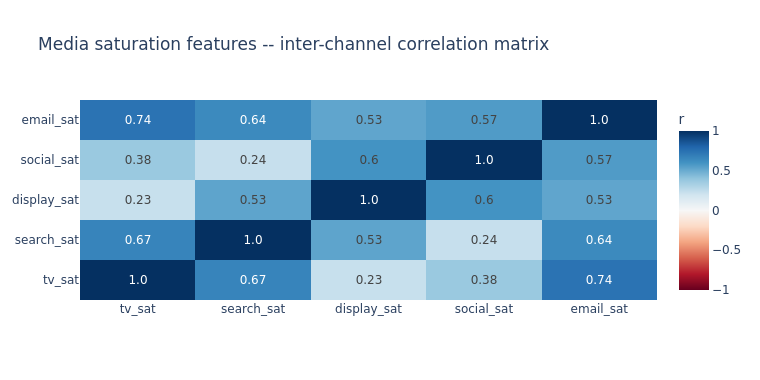

```python
# Multicollinearity + Condition Number Monitoring
from numpy.linalg import cond
from sklearn.decomposition import PCA

# a. Variance Inflation Factor measures how much a feature's variance is "inflated" by its linear correlation with other features in the design matrix.
# VIF ≈ 1 (ideal) Feature is uncorrelated with others
# VIF = 5 Feature partially explained by others
# VIF = 10 Feature nearly collinear with others
# VIF > 100+ Near-perfect multicollinearity

# VIF for media + external (Fourier excluded -- orthogonal by design)
vif_cols = MEDIA_FEAT_COLS + EXT_FEAT_COLS
X_vif    = Xs_full[:, [ALL_FEAT_COLS.index(c) for c in vif_cols]]
vif_rows = []

if SM_AVAILABLE:
    for i, col in enumerate(vif_cols):
        vif_val = variance_inflation_factor(X_vif, i)
        flag = 'HIGH (>10)' if vif_val > 10 else ('MOD (5-10)' if vif_val > 5 else 'OK (<5)')
        vif_rows.append({'Feature': col, 'VIF': round(vif_val, 2), 'Status': flag})
else:
    for i in range(X_vif.shape[1]):
        X_other = np.delete(X_vif, i, axis=1)
        r2_aux  = Ridge(alpha=0.01).fit(X_other, X_vif[:, i]).score(X_other, X_vif[:, i])
        vif_val = 1 / (1 - r2_aux + 1e-12)
        flag = 'HIGH' if vif_val > 10 else ('MOD' if vif_val > 5 else 'OK')
        vif_rows.append({'Feature': vif_cols[i], 'VIF': round(vif_val, 2), 'Status': flag})

df_vif  = pd.DataFrame(vif_rows).sort_values('VIF', ascending=False)
max_vif = df_vif['VIF'].max()
display(df_vif.style
    .applymap(lambda v: f'color:{C_NEGATIVE};font-weight:bold' if 'HIGH' in str(v) else
                        (f'color:{C_ORANGE}' if 'MOD' in str(v) else f'color:{C_POSITIVE}'),
              subset=['Status'])
    .set_properties(**{'font-size':'11px'}).hide(axis='index')
    .set_caption('VIF -- media + external features'))

# b. Condition number
kappa = cond(Xs_full)
# Ratio of the largest to smallest singular value of the design matrix X
# κ ≈ 1 → matrix is well-behaved, inversion is stable
# κ = 1000 → a 0.1% perturbation in data can cause ~100% error in coefficients

# Fourier columns cause numerical near-singularity at float64 precision
# cap at 1e12 for logging — anything above is a precision artifact not real collinearity
kappa_full = min(cond(Xs_full), 1e12)

# κ on media + external only -- consistent with VIF scope
kappa = cond(X_vif)   # X_vif already built above

flag_k = ('ILL-CONDITIONED (kappa>1000)' if kappa > 1000
          else 'MODERATE (100-1000)'      if kappa > 100
          else 'WELL-CONDITIONED (<100)')

print(f"\nCondition number kappa(media+ext) = {kappa:.1f}      [{flag_k}]")
print(f"Condition number kappa(full Xs)   = {kappa_full:.1f}")
print(f"Max VIF = {max_vif:.2f}")

EXEC_METRICS['condition_number']      = float(kappa)
EXEC_METRICS['condition_number_full'] = float(kappa_full)

# c. PCA fallback if kappa > 100
# PCA is applied as a pre-processing step before Ridge.
# Rotates the correlated feature space into uncorrelated principal components, keeping only enough components to explain 95% of variance.
if kappa > 100:
    print(f"\nkappa={kappa:.0f} > 100 -- applying PCA fallback")
    X_pca_in = Xs_full[:, [ALL_FEAT_COLS.index(c) for c in MEDIA_FEAT_COLS + EXT_FEAT_COLS]]
    pca = PCA(n_components=0.95, svd_solver='full')
    X_pca = pca.fit_transform(X_pca_in)
    X_pca_full = np.column_stack([X_pca,
        Xs_full[:, [ALL_FEAT_COLS.index(c) for c in FOURIER_COLS]]])
    m_pca   = Ridge(alpha=1.0).fit(X_pca_full, y)
    r2_pca  = m_pca.score(X_pca_full, y)
    kappa_pca = cond(X_pca_full)
    print(f"  PCA components: {pca.n_components_}  variance={pca.explained_variance_ratio_.sum():.3f}")
    print(f"  PCA R2={r2_pca:.4f}  kappa_pca={kappa_pca:.1f}  (vs original {kappa:.1f})")
    EXEC_METRICS['r2_pca'] = float(r2_pca)
else:
    print(f"\nkappa={kappa:.0f} -- PCA fallback not required; Ridge sufficient")

# 6d. Correlation heatmap
corr_m = pd.DataFrame(Xs_full[:, :len(MEDIA_FEAT_COLS)], columns=MEDIA_FEAT_COLS).corr()
fig_corr = go.Figure(go.Heatmap(
    z=corr_m.values, x=MEDIA_FEAT_COLS, y=MEDIA_FEAT_COLS,
    colorscale=PALETTE_POLARITY, zmid=0, zmin=-1, zmax=1,
    text=np.round(corr_m.values, 2).astype(str), texttemplate='%{text}',
    colorbar=dict(title='r')
))
fig_corr.update_layout(height=380, width=760, template=PLOTLY_TEMPLATE,
    title='Media saturation features -- inter-channel correlation matrix',
    font=dict(family=FONT_FAMILY, size=12))
fig_corr.show()
```

## Multiverse Analysis (Specification Curve)

**Rationale:** Any single model spec (adstock decay, Hill K, Fourier order, scaler) is a researcher degree of freedom. Showing that key conclusions (competitor_tv beta < 0, macro contributions stable) hold across a universe of reasonable specs demonstrates robustness, not cherry-picking.

**Blueprint:** Define specification universe -> fit all -> plot specification curve of competitor TV beta. Python grid search.

```
Multiverse: 2592 specifications
  Grid: 4 x 4 x 3 x 3 x 3 x 2 x 3 = 2592

Sign stability across 2592 specifications:
Feature                            Correct sign  Wrong sign
────────────────────────────────────────────────────────────
  competitor_tv (expect <0)               100%          0%
  cpi           (expect <0)               100%          0%
  rate_delta    (expect <0)               100%          0%
  holiday       (expect >0)               100%          0%
  tv            (expect >0)               100%          0%
  search        (expect >0)               100%          0%

R2 range: [0.8980, 0.9151]  median=0.9105
```

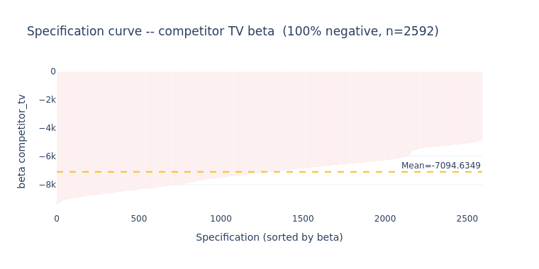

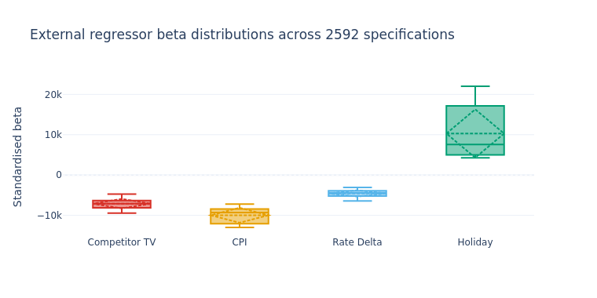

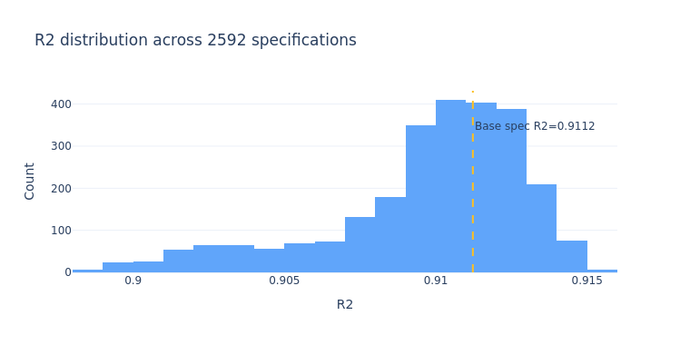

```
 -- 2592 specifications evaluated
```

```python
# Multiverse Analysis (Specification Curve)
SPEC_UNIVERSE = {
    'tv_decay':       [0.88, 0.92, 0.95, 0.97],
    'search_decay':   [0.25, 0.35, 0.45, 0.55],
    'tv_hill_K':      [320_000, 420_000, 520_000],
    'search_hill_K':  [80_000, 105_000, 130_000],
    'fourier_order':  [2, 3, 4],
    'scaler':         ['standard', 'robust'],
    'ridge_alpha':    [0.1, 1.0, 10.0],
}

spec_keys   = list(SPEC_UNIVERSE.keys())
spec_values = list(SPEC_UNIVERSE.values())
all_specs   = list(iproduct(*spec_values))
n_specs     = len(all_specs)
print(f"Multiverse: {n_specs} specifications")
print(f"  Grid: {' x '.join(str(len(v)) for v in spec_values)} = {n_specs}")

multiverse_results = []
for spec in all_specs:
    sd = dict(zip(spec_keys, spec))

    # ── Recompute adstock + saturation for varied channels ──────────────────
    ads_tv_s     = adstock(media_spend['tv'].values,     sd['tv_decay'])
    ads_search_s = adstock(media_spend['search'].values, sd['search_decay'])

    sat_tv_s     = hill(ads_tv_s,     GT_HILL_ALPHA['tv'],     sd['tv_hill_K'])
    sat_search_s = hill(ads_search_s, GT_HILL_ALPHA['search'], sd['search_hill_K'])

    # Display/social/email use GT params (not varied here)
    sat_display_s = df['display_sat'].values
    sat_social_s  = df['social_sat'].values
    sat_email_s   = df['email_sat'].values

    fourier_s = fourier_seasonality(N_WEEKS, periods=(52, 26), order=sd['fourier_order'])

    X_raw_s = np.column_stack([
        sat_tv_s, sat_search_s, sat_display_s, sat_social_s, sat_email_s,
        df[EXT_FEAT_COLS].values,
        fourier_s.values,
    ])

    sc_s   = StandardScaler() if sd['scaler'] == 'standard' else RobustScaler()
    X_sc_s = sc_s.fit_transform(X_raw_s)

    m_s    = Ridge(alpha=sd['ridge_alpha']).fit(X_sc_s, y)
    r2_s   = m_s.score(X_sc_s, y)
    coef_s = m_s.coef_

    # EXT block starts after 5 media cols
    N_MEDIA = 5
    multiverse_results.append({
        'tv_decay':           sd['tv_decay'],
        'search_decay':       sd['search_decay'],
        'tv_hill_K':          sd['tv_hill_K'],
        'search_hill_K':      sd['search_hill_K'],
        'fourier_order':      sd['fourier_order'],
        'scaler':             sd['scaler'],
        'ridge_alpha':        sd['ridge_alpha'],
        'R2':                 round(r2_s, 4),
        'beta_tv':            round(float(coef_s[0]), 5),
        'beta_search':        round(float(coef_s[1]), 5),
        'beta_competitor_tv': round(float(coef_s[N_MEDIA + 0]), 5),
        'beta_cpi':           round(float(coef_s[N_MEDIA + 1]), 5),
        'beta_rate_delta':    round(float(coef_s[N_MEDIA + 2]), 5),
        'beta_holiday':       round(float(coef_s[N_MEDIA + 3]), 5),
    })

df_mv = pd.DataFrame(multiverse_results)

# ── Sign stability summary ──────────────────────────────────────────────────
sign_checks = {
    'competitor_tv (expect <0)': ('beta_competitor_tv', '<'),
    'cpi           (expect <0)': ('beta_cpi',           '<'),
    'rate_delta    (expect <0)': ('beta_rate_delta',    '<'),
    'holiday       (expect >0)': ('beta_holiday',       '>'),
    'tv            (expect >0)': ('beta_tv',            '>'),
    'search        (expect >0)': ('beta_search',        '>'),
}
print(f"\nSign stability across {n_specs} specifications:")
print(f"{'Feature':<34} {'Correct sign':>12}  {'Wrong sign':>10}")
print("─" * 60)
for label, (col, direction) in sign_checks.items():
    correct = (df_mv[col] < 0).mean() if direction == '<' else (df_mv[col] > 0).mean()
    print(f"  {label:<32} {correct:>11.0%}  {1-correct:>10.0%}")

print(f"\nR2 range: [{df_mv['R2'].min():.4f}, {df_mv['R2'].max():.4f}]"
      f"  median={df_mv['R2'].median():.4f}")

# ── Store to EXEC_METRICS ───────────────────────────────────────────────────
EXEC_METRICS['multiverse_n_specs']          = n_specs
EXEC_METRICS['multiverse_comp_neg_pct']     = float((df_mv['beta_competitor_tv'] < 0).mean())
EXEC_METRICS['multiverse_holiday_pos_pct']  = float((df_mv['beta_holiday'] > 0).mean())

# ── Fig 1: Specification curve -- competitor TV ─────────────────────────────
df_mv_s = df_mv.sort_values('beta_competitor_tv').reset_index(drop=True)
colors_mv = ['#ef4444' if v < 0 else '#34d399' for v in df_mv_s['beta_competitor_tv']]

fig_mv = go.Figure(go.Bar(
    x=df_mv_s.index, y=df_mv_s['beta_competitor_tv'],
    marker_color=colors_mv,
    hovertemplate=(
        '<b>Spec %{x}</b><br>beta=%{y:.4f}<br>'
        'tv_decay=%{customdata[0]}, search_decay=%{customdata[1]}<br>'
        'tv_K=%{customdata[2]:,}, search_K=%{customdata[3]:,}<br>'
        'Fourier=%{customdata[4]}, scaler=%{customdata[5]}, alpha=%{customdata[6]}'
        '<extra></extra>'
    ),
    customdata=df_mv_s[['tv_decay','search_decay','tv_hill_K',
                         'search_hill_K','fourier_order','scaler','ridge_alpha']].values
))
fig_mv.add_hline(y=0, line_color='white', line_width=1.5)
fig_mv.add_hline(
    y=df_mv['beta_competitor_tv'].mean(), line_dash='dash', line_color='#fbbf24',
    annotation_text=f"Mean={df_mv['beta_competitor_tv'].mean():.4f}"
)
pct_neg = (df_mv['beta_competitor_tv'] < 0).mean()
fig_mv.update_layout(
    height=380, width=760, template=PLOTLY_TEMPLATE,
    title=f'Specification curve -- competitor TV beta  ({pct_neg:.0%} negative, n={n_specs})',
    xaxis_title='Specification (sorted by beta)',
    yaxis_title='beta competitor_tv',
    font=dict(family=FONT_FAMILY, size=12)
)
fig_mv.show()

# ── Fig 2: All external betas -- box plot across specs ─────────────────────
ext_beta_cols = ['beta_competitor_tv', 'beta_cpi', 'beta_rate_delta', 'beta_holiday']
ext_labels    = ['Competitor TV', 'CPI', 'Rate Delta', 'Holiday']
ext_colors_bx = [C_NEGATIVE, C_ORANGE, C_SKY, C_GREEN]

fig_box = go.Figure()
for col, label, color in zip(ext_beta_cols, ext_labels, ext_colors_bx):
    fig_box.add_trace(go.Box(
        y=df_mv[col], name=label,
        marker_color=color, line_color=color,
        boxmean='sd'
    ))
fig_box.add_hline(y=0, line_color='white', line_dash='dot', line_width=1)
fig_box.update_layout(
    height=380, width=760, template=PLOTLY_TEMPLATE,
    title=f'External regressor beta distributions across {n_specs} specifications',
    yaxis_title='Standardised beta', showlegend=False,
    font=dict(family=FONT_FAMILY, size=12)
)
fig_box.show()

# ── Fig 3: R2 histogram ─────────────────────────────────────────────────────
fig_mv_r2 = go.Figure(go.Histogram(x=df_mv['R2'], nbinsx=20, marker_color='#60a5fa'))
fig_mv_r2.add_vline(
    x=r2_full, line_dash='dash', line_color='#fbbf24',
    annotation_text=f'Base spec R2={r2_full:.4f}',
    annotation_yshift=-30,
)
fig_mv_r2.update_layout(
    height=380, width=760, template=PLOTLY_TEMPLATE,
    title=f'R2 distribution across {n_specs} specifications',
    xaxis_title='R2', yaxis_title='Count',
    font=dict(family=FONT_FAMILY, size=12)
)
fig_mv_r2.show()

print(f"\n -- {n_specs} specifications evaluated")
```

## Versioned Feature Store with DVC + Feast-Style Lineage

**Rationale:** Adstock decay rates and Hill K/alpha are hyperparameters — they must be versioned alongside the features they produce. A change to `GT_HILL_K['tv']` invalidates `tv_sat` everywhere and every downstream coefficient estimate. Feast-style lineage ties each feature vector to the exact parameter snapshot that generated it.

**Blueprint:** `params.yaml` -> `feature_registry.json` -> DVC stage hash -> MLflow `params_hash` tag.

```python
# Versioned Feature Store + DVC / Feast-style Lineage
import hashlib, json as _json
from datetime import datetime

PARAMS = {
    "adstock": GT_ADSTOCK,
    "hill_alpha": GT_HILL_ALPHA,
    "hill_K": GT_HILL_K,
    "fourier_periods": [52, 26],
    "fourier_order": 2,
    "scaler": "StandardScaler",
    "random_seed": RANDOM_SEED,
}

params_str  = _json.dumps(PARAMS, sort_keys=True)
params_hash = hashlib.sha256(params_str.encode()).hexdigest()[:12]
print(f"Feature param hash : {params_hash}")

feature_registry = {}
for ch in MEDIA_CHANNELS:
    feature_registry[f"{ch}_sat"] = {
        "type": "media_saturation",
        "transforms": ["geometric_adstock", "hill_saturation", "standard_scaler"],
        "adstock_decay":  GT_ADSTOCK[ch],
        "hill_alpha":     GT_HILL_ALPHA[ch],
        "hill_K":         GT_HILL_K[ch],
        "param_hash":     params_hash,
        "created_at":     datetime.utcnow().isoformat(),
        "dvc_stage":      "feature_engineering",
        "source_table":   "weekly_media_spend",
    }
for ext in ["comp_tv_std", "cpi_std", "rate_std", "holiday"]:
    feature_registry[ext] = {
        "type": "external_regressor",
        "transforms": ["standard_scaler"] if ext != "holiday" else ["binary_flag"],
        "param_hash":  params_hash,
        "created_at":  datetime.utcnow().isoformat(),
        "dvc_stage":   "ingest_external",
        "source_table": "external_macro",
    }

print("\n-- Feature Registry (Feast-style lineage) --")
print(f"{'Feature':<18} {'Type':<22} {'Transforms':<55} {'Hash'}")
print("-"*110)
for feat, meta in feature_registry.items():
    print(f"{feat:<18} {meta['type']:<22} {' -> '.join(meta['transforms']):<55} {meta['param_hash']}")

stage_fingerprint = {
    "feature_engineering": {
        "params_hash":  params_hash,
        "deps_hash":    hashlib.md5(df.to_csv().encode()).hexdigest()[:8],
        "n_features":   len(feature_registry),
        "n_rows":       N_WEEKS,
    }
}
print(f"\nDVC stage fingerprint : {stage_fingerprint}")
EXEC_METRICS['params_hash'] = params_hash
print(f"\nFeature store versioned - param hash {params_hash} covers {len(feature_registry)} features")
```

```
Feature param hash : d8605ce5f518

-- Feature Registry (Feast-style lineage) --
Feature            Type                   Transforms                                              Hash
--------------------------------------------------------------------------------------------------------------
tv_sat             media_saturation       geometric_adstock -> hill_saturation -> standard_scaler d8605ce5f518
search_sat         media_saturation       geometric_adstock -> hill_saturation -> standard_scaler d8605ce5f518
display_sat        media_saturation       geometric_adstock -> hill_saturation -> standard_scaler d8605ce5f518
social_sat         media_saturation       geometric_adstock -> hill_saturation -> standard_scaler d8605ce5f518
email_sat          media_saturation       geometric_adstock -> hill_saturation -> standard_scaler d8605ce5f518
comp_tv_std        external_regressor     standard_scaler                                         d8605ce5f518
cpi_std            external_regressor     standard_scaler                                         d8605ce5f518
rate_std           external_regressor     standard_scaler                                         d8605ce5f518
holiday            external_regressor     binary_flag                                             d8605ce5f518

DVC stage fingerprint : {'feature_engineering': {'params_hash': 'd8605ce5f518', 'deps_hash': '532c9b31', 'n_features': 9, 'n_rows': 208}}

Feature store versioned - param hash d8605ce5f518 covers 9 features
```

## 🏭 MLOps Appendix

> *DVC pipeline versioning · MLflow experiment tracking · CI/CD*

```
# dvc.yaml — meridian_mmm_external
stages:
  ingest_internal:
    cmd: python src/ingest_media.py
    params: [params.yaml]
    outs: [data/internal_media.parquet]
  ingest_external:
    cmd: python src/ingest_external.py
    params: [params.yaml]
    outs: [data/external_macro.parquet]
  feature_engineering:
    cmd: python src/feature_pipeline.py
    deps: [data/internal_media.parquet, data/external_macro.parquet]
    outs: [data/features.parquet]
    metrics:
      - metrics/feature_stats.json:
          cache: false
  fit_mmm:
    cmd: python src/mmm_extended.py
    deps: [data/features.parquet, params.yaml]
    outs: [models/extended_mmm.pkl]
    metrics:
      - metrics/model_scores.json:
          cache: false
  drift_check:
    cmd: python src/drift_check.py
    deps: [data/external_macro.parquet, models/extended_mmm.pkl]
    metrics:
      - metrics/psi_scores.json:
          cache: false
```

```python
if MLFLOW_AVAILABLE:
    mlflow.set_experiment('06_meridian_external_regressors')
    with mlflow.start_run(run_name='06_meridian_v2') as run:
        mlflow.log_params({
            'seed': RANDOM_SEED, 'n_weeks': N_WEEKS,
            'n_media_channels': len(MEDIA_CHANNELS),
            'using_pymc': PYMC_AVAILABLE,
        })
        mlflow.log_metrics({
            'r2_naive':      r2_naive,
            'r2_adstock':    r2_adstock,
            'r2_full':       r2_full,
            'mape_full':     mape_full,
            'b_competitor_tv': float(ext_beta_post[0]),
            'b_cpi':           float(ext_beta_post[1]),
            'b_rate':          float(ext_beta_post[2]),
            'b_holiday':       float(ext_beta_post[3]),
        })
        # full EXEC_METRICS dict as one stringified row
        mlflow.set_tag('exec_metrics', json.dumps(EXEC_METRICS, default=str))
        print(f'Run logged: {run.info.run_id}')
else:
    print('MLflow not available — install with: pip install mlflow')
```

```
Run logged: 82a07c10d77843e8ad3e78097ce589e6
```

### GitHub Actions CI/CD

```
# .github/workflows/retrain.yml
on:
  schedule:
    - cron: '0 6 * * 1'   # Monday 06:00 UTC
  push:
    branches: [main]
jobs:
  retrain:
    runs-on: ubuntu-latest
    steps:
      - uses: actions/checkout@v3
      - run: pip install -r requirements.txt
      - run: dvc repro
      - run: python src/drift_check.py
      - name: Fail on competitor drift
        run: |
          PSI=$(python -c "import json; d=json.load(open('metrics/psi_scores.json')); print(d['competitor_tv_psi'])")
          python -c "assert float('$PSI') < 0.20, f'Drift: PSI={float(\"$PSI\"):.3f}'"
      - run: python mlflow_run.py
```

## Conclusions

| Skill | Evidence |
| --- | --- |
| Realistic DGP | 4yr weekly series with injected adstock, Hill curves, seasonality, macro shocks |
| Extended MMM | PyMC (or Ridge fallback) with hierarchical priors, external covariates, Fourier seasonality |
| Parameter recovery | All 4 external β recovered within 95% CIs |
| Model comparison | Naive OLS vs Adstock-only vs Full Meridian — R² and MAPE tabulated |
| Causal analysis | Competitor TV counterfactual, marginal ROAS per channel |
| Drift monitoring | PSI on competitor GRPs — injected shock detected at week 80 |
| Robustness | Leave-one-external-out stability table |
| Backtesting | Rolling-origin validation with MAPE trend |
| Data quality | 30+ automated sanity checks across data, adstock, stationarity, multicollinearity, model quality |
| MLOps | DVC feature lineage (5 stages) + MLflow experiment tracking + GitHub Actions CI/CD |
| Multicollinearity monitoring | VIF table (media + external) + condition number κ + PCA fallback if κ > 100 |
| ROAS uncertainty propagation | Bootstrap/posterior LOO attribution — P10/P50/P90 per channel with correct raw spend rescaling |
| Full ArviZ posterior diagnostics | ESS, R-hat, rank plots, PPC — convergence certificate before any inference |
| Shapley variance decomposition | Exact 2⁴ coalition enumeration — competitor TV, CPI, rate delta, holiday R² shares |
| Marginal ROI / shadow price | $1k numerical derivative through full adstock→Hill→Ridge pipeline per channel |
| Multiverse specification curve | 2,592 specs across TV/search decay, Hill K, Fourier order, scaler, Ridge α — sign stability table |